# EDA Case Study

### Problem Statements :

> - Identify patterns which indicate if a client has difficulty paying their installments
> - Use EDA to analyse the pattern present in the data and ensure that the applicants capable of repaying the loan are not rejected and defaulters should not get the loan.

#### EDA Case Study by : Ateendra Jha

### Approach of Analysis

#### **Importing the required libraries.**

```python
import pandas as pd
import numpy as np
import matplotlib.pyplot as plt
import seaborn as sns
import warnings
warnings.filterwarnings('ignore')
```

#### Reading the Application Dataset

```python
CurrentAppl = pd.read_csv('application_data.csv')
CurrentAppl.head()
```

|  | SK_ID_CURR | TARGET | NAME_CONTRACT_TYPE | CODE_GENDER | FLAG_OWN_CAR | FLAG_OWN_REALTY | CNT_CHILDREN | AMT_INCOME_TOTAL | AMT_CREDIT | AMT_ANNUITY | ... | FLAG_DOCUMENT_18 | FLAG_DOCUMENT_19 | FLAG_DOCUMENT_20 | FLAG_DOCUMENT_21 | AMT_REQ_CREDIT_BUREAU_HOUR | AMT_REQ_CREDIT_BUREAU_DAY | AMT_REQ_CREDIT_BUREAU_WEEK | AMT_REQ_CREDIT_BUREAU_MON | AMT_REQ_CREDIT_BUREAU_QRT | AMT_REQ_CREDIT_BUREAU_YEAR |
| --- | --- | --- | --- | --- | --- | --- | --- | --- | --- | --- | --- | --- | --- | --- | --- | --- | --- | --- | --- | --- | --- |
| 0 | 100002 | 1 | Cash loans | M | N | Y | 0 | 202500.0 | 406597.5 | 24700.5 | ... | 0 | 0 | 0 | 0 | 0.0 | 0.0 | 0.0 | 0.0 | 0.0 | 1.0 |
| 1 | 100003 | 0 | Cash loans | F | N | N | 0 | 270000.0 | 1293502.5 | 35698.5 | ... | 0 | 0 | 0 | 0 | 0.0 | 0.0 | 0.0 | 0.0 | 0.0 | 0.0 |
| 2 | 100004 | 0 | Revolving loans | M | Y | Y | 0 | 67500.0 | 135000.0 | 6750.0 | ... | 0 | 0 | 0 | 0 | 0.0 | 0.0 | 0.0 | 0.0 | 0.0 | 0.0 |
| 3 | 100006 | 0 | Cash loans | F | N | Y | 0 | 135000.0 | 312682.5 | 29686.5 | ... | 0 | 0 | 0 | 0 | NaN | NaN | NaN | NaN | NaN | NaN |
| 4 | 100007 | 0 | Cash loans | M | N | Y | 0 | 121500.0 | 513000.0 | 21865.5 | ... | 0 | 0 | 0 | 0 | 0.0 | 0.0 | 0.0 | 0.0 | 0.0 | 0.0 |

5 rows × 122 columns

#### Reading the Previous Application Dataset

```python
PrevAppl =  pd.read_csv('previous_application.csv')
PrevAppl.head()
```

|  | SK_ID_PREV | SK_ID_CURR | NAME_CONTRACT_TYPE | AMT_ANNUITY | AMT_APPLICATION | AMT_CREDIT | AMT_DOWN_PAYMENT | AMT_GOODS_PRICE | WEEKDAY_APPR_PROCESS_START | HOUR_APPR_PROCESS_START | ... | NAME_SELLER_INDUSTRY | CNT_PAYMENT | NAME_YIELD_GROUP | PRODUCT_COMBINATION | DAYS_FIRST_DRAWING | DAYS_FIRST_DUE | DAYS_LAST_DUE_1ST_VERSION | DAYS_LAST_DUE | DAYS_TERMINATION | NFLAG_INSURED_ON_APPROVAL |
| --- | --- | --- | --- | --- | --- | --- | --- | --- | --- | --- | --- | --- | --- | --- | --- | --- | --- | --- | --- | --- | --- |
| 0 | 2030495 | 271877 | Consumer loans | 1730.430 | 17145.0 | 17145.0 | 0.0 | 17145.0 | SATURDAY | 15 | ... | Connectivity | 12.0 | middle | POS mobile with interest | 365243.0 | -42.0 | 300.0 | -42.0 | -37.0 | 0.0 |
| 1 | 2802425 | 108129 | Cash loans | 25188.615 | 607500.0 | 679671.0 | NaN | 607500.0 | THURSDAY | 11 | ... | XNA | 36.0 | low_action | Cash X-Sell: low | 365243.0 | -134.0 | 916.0 | 365243.0 | 365243.0 | 1.0 |
| 2 | 2523466 | 122040 | Cash loans | 15060.735 | 112500.0 | 136444.5 | NaN | 112500.0 | TUESDAY | 11 | ... | XNA | 12.0 | high | Cash X-Sell: high | 365243.0 | -271.0 | 59.0 | 365243.0 | 365243.0 | 1.0 |
| 3 | 2819243 | 176158 | Cash loans | 47041.335 | 450000.0 | 470790.0 | NaN | 450000.0 | MONDAY | 7 | ... | XNA | 12.0 | middle | Cash X-Sell: middle | 365243.0 | -482.0 | -152.0 | -182.0 | -177.0 | 1.0 |
| 4 | 1784265 | 202054 | Cash loans | 31924.395 | 337500.0 | 404055.0 | NaN | 337500.0 | THURSDAY | 9 | ... | XNA | 24.0 | high | Cash Street: high | NaN | NaN | NaN | NaN | NaN | NaN |

5 rows × 37 columns

### EDA on Application dataset

#### Cleaning the Data

- Checking Data Types
- Checking Missing values
- Handeling MIssing values
- Handling Wrongly structured Data
- Converting Data in required format

```python
print('Columns in Application dataset is :', CurrentAppl.shape[-1])
```

```
Columns in Application dataset is : 122
```

```python
# Locating columns >50% empty cells
emptycol = CurrentAppl.isnull().sum()
col50null = emptycol[emptycol.values > 0.5*len(emptycol)]
print('No. of columns having more than 50% of the empty values (in Application file) :', len(col50null))
```

```
No. of columns having more than 50% of the empty values (in Application file) : 64
```

As there are 64 columns which has > 50% of empty cells. We can prefer to drop these columns.

```python
# Dropping columns >50% empty cells
col50null = list(col50null.index)
CurrentAppl = CurrentAppl.drop( labels=col50null, axis=1 )
print( 'No. of columns left after dropping the columns :' ,CurrentAppl.shape[-1])
print('Number of entries in application data :', CurrentAppl.shape[0] )
```

```
No. of columns left after dropping the columns : 58
Number of entries in application data : 307511
```

```python
# We will remove unwanted columns from this dataset

unwanted=['FLAG_MOBIL', 'FLAG_EMP_PHONE', 'FLAG_WORK_PHONE', 'FLAG_CONT_MOBILE',
       'FLAG_PHONE', 'FLAG_EMAIL','REGION_RATING_CLIENT','REGION_RATING_CLIENT_W_CITY','FLAG_EMAIL','CNT_FAM_MEMBERS', 'REGION_RATING_CLIENT',
       'REGION_RATING_CLIENT_W_CITY','DAYS_LAST_PHONE_CHANGE', 'FLAG_DOCUMENT_2', 'FLAG_DOCUMENT_3','FLAG_DOCUMENT_4', 'FLAG_DOCUMENT_5', 'FLAG_DOCUMENT_6',
       'FLAG_DOCUMENT_7', 'FLAG_DOCUMENT_8', 'FLAG_DOCUMENT_9','FLAG_DOCUMENT_10', 'FLAG_DOCUMENT_11', 'FLAG_DOCUMENT_12',
       'FLAG_DOCUMENT_13', 'FLAG_DOCUMENT_14', 'FLAG_DOCUMENT_15','FLAG_DOCUMENT_16', 'FLAG_DOCUMENT_17', 'FLAG_DOCUMENT_18',
       'FLAG_DOCUMENT_19', 'FLAG_DOCUMENT_20', 'FLAG_DOCUMENT_21']

CurrentAppl.drop(labels=unwanted,axis=1,inplace=True)
```

```python
CurrentAppl.head()
```

|  | SK_ID_CURR | TARGET | NAME_CONTRACT_TYPE | CODE_GENDER | FLAG_OWN_CAR | FLAG_OWN_REALTY | CNT_CHILDREN | AMT_INCOME_TOTAL | AMT_CREDIT | AMT_ANNUITY | ... | DAYS_ID_PUBLISH | WEEKDAY_APPR_PROCESS_START | HOUR_APPR_PROCESS_START | REG_REGION_NOT_LIVE_REGION | REG_REGION_NOT_WORK_REGION | LIVE_REGION_NOT_WORK_REGION | REG_CITY_NOT_LIVE_CITY | REG_CITY_NOT_WORK_CITY | LIVE_CITY_NOT_WORK_CITY | ORGANIZATION_TYPE |
| --- | --- | --- | --- | --- | --- | --- | --- | --- | --- | --- | --- | --- | --- | --- | --- | --- | --- | --- | --- | --- | --- |
| 0 | 100002 | 1 | Cash loans | M | N | Y | 0 | 202500.0 | 406597.5 | 24700.5 | ... | -2120 | WEDNESDAY | 10 | 0 | 0 | 0 | 0 | 0 | 0 | Business Entity Type 3 |
| 1 | 100003 | 0 | Cash loans | F | N | N | 0 | 270000.0 | 1293502.5 | 35698.5 | ... | -291 | MONDAY | 11 | 0 | 0 | 0 | 0 | 0 | 0 | School |
| 2 | 100004 | 0 | Revolving loans | M | Y | Y | 0 | 67500.0 | 135000.0 | 6750.0 | ... | -2531 | MONDAY | 9 | 0 | 0 | 0 | 0 | 0 | 0 | Government |
| 3 | 100006 | 0 | Cash loans | F | N | Y | 0 | 135000.0 | 312682.5 | 29686.5 | ... | -2437 | WEDNESDAY | 17 | 0 | 0 | 0 | 0 | 0 | 0 | Business Entity Type 3 |
| 4 | 100007 | 0 | Cash loans | M | N | Y | 0 | 121500.0 | 513000.0 | 21865.5 | ... | -3458 | THURSDAY | 11 | 0 | 0 | 0 | 0 | 1 | 1 | Religion |

5 rows × 28 columns

```python
# Describing the numerical data
CurrentAppl.describe()
```

|  | SK_ID_CURR | TARGET | CNT_CHILDREN | AMT_INCOME_TOTAL | AMT_CREDIT | AMT_ANNUITY | REGION_POPULATION_RELATIVE | DAYS_BIRTH | DAYS_EMPLOYED | DAYS_REGISTRATION | DAYS_ID_PUBLISH | HOUR_APPR_PROCESS_START | REG_REGION_NOT_LIVE_REGION | REG_REGION_NOT_WORK_REGION | LIVE_REGION_NOT_WORK_REGION | REG_CITY_NOT_LIVE_CITY | REG_CITY_NOT_WORK_CITY | LIVE_CITY_NOT_WORK_CITY |
| --- | --- | --- | --- | --- | --- | --- | --- | --- | --- | --- | --- | --- | --- | --- | --- | --- | --- | --- |
| count | 307511.000000 | 307511.000000 | 307511.000000 | 3.075110e+05 | 3.075110e+05 | 307499.000000 | 307511.000000 | 307511.000000 | 307511.000000 | 307511.000000 | 307511.000000 | 307511.000000 | 307511.000000 | 307511.000000 | 307511.000000 | 307511.000000 | 307511.000000 | 307511.000000 |
| mean | 278180.518577 | 0.080729 | 0.417052 | 1.687979e+05 | 5.990260e+05 | 27108.573909 | 0.020868 | -16036.995067 | 63815.045904 | -4986.120328 | -2994.202373 | 12.063419 | 0.015144 | 0.050769 | 0.040659 | 0.078173 | 0.230454 | 0.179555 |
| std | 102790.175348 | 0.272419 | 0.722121 | 2.371231e+05 | 4.024908e+05 | 14493.737315 | 0.013831 | 4363.988632 | 141275.766519 | 3522.886321 | 1509.450419 | 3.265832 | 0.122126 | 0.219526 | 0.197499 | 0.268444 | 0.421124 | 0.383817 |
| min | 100002.000000 | 0.000000 | 0.000000 | 2.565000e+04 | 4.500000e+04 | 1615.500000 | 0.000290 | -25229.000000 | -17912.000000 | -24672.000000 | -7197.000000 | 0.000000 | 0.000000 | 0.000000 | 0.000000 | 0.000000 | 0.000000 | 0.000000 |
| 25% | 189145.500000 | 0.000000 | 0.000000 | 1.125000e+05 | 2.700000e+05 | 16524.000000 | 0.010006 | -19682.000000 | -2760.000000 | -7479.500000 | -4299.000000 | 10.000000 | 0.000000 | 0.000000 | 0.000000 | 0.000000 | 0.000000 | 0.000000 |
| 50% | 278202.000000 | 0.000000 | 0.000000 | 1.471500e+05 | 5.135310e+05 | 24903.000000 | 0.018850 | -15750.000000 | -1213.000000 | -4504.000000 | -3254.000000 | 12.000000 | 0.000000 | 0.000000 | 0.000000 | 0.000000 | 0.000000 | 0.000000 |
| 75% | 367142.500000 | 0.000000 | 1.000000 | 2.025000e+05 | 8.086500e+05 | 34596.000000 | 0.028663 | -12413.000000 | -289.000000 | -2010.000000 | -1720.000000 | 14.000000 | 0.000000 | 0.000000 | 0.000000 | 0.000000 | 0.000000 | 0.000000 |
| max | 456255.000000 | 1.000000 | 19.000000 | 1.170000e+08 | 4.050000e+06 | 258025.500000 | 0.072508 | -7489.000000 | 365243.000000 | 0.000000 | 0.000000 | 23.000000 | 1.000000 | 1.000000 | 1.000000 | 1.000000 | 1.000000 | 1.000000 |

```python
# Getting the data type
CurrentAppl.info()
```

```
<class 'pandas.core.frame.DataFrame'>
RangeIndex: 307511 entries, 0 to 307510
Data columns (total 28 columns):
 #   Column                       Non-Null Count   Dtype
---  ------                       --------------   -----
 0   SK_ID_CURR                   307511 non-null  int64
 1   TARGET                       307511 non-null  int64
 2   NAME_CONTRACT_TYPE           307511 non-null  object
 3   CODE_GENDER                  307511 non-null  object
 4   FLAG_OWN_CAR                 307511 non-null  object
 5   FLAG_OWN_REALTY              307511 non-null  object
 6   CNT_CHILDREN                 307511 non-null  int64
 7   AMT_INCOME_TOTAL             307511 non-null  float64
 8   AMT_CREDIT                   307511 non-null  float64
 9   AMT_ANNUITY                  307499 non-null  float64
```

[output cut: 20 more lines]

```python
# Checking the columns having null values

CurrentAppl.isnull().sum()/len(CurrentAppl)*100
```

```
SK_ID_CURR                     0.000000
TARGET                         0.000000
NAME_CONTRACT_TYPE             0.000000
CODE_GENDER                    0.000000
FLAG_OWN_CAR                   0.000000
FLAG_OWN_REALTY                0.000000
CNT_CHILDREN                   0.000000
AMT_INCOME_TOTAL               0.000000
AMT_CREDIT                     0.000000
AMT_ANNUITY                    0.003902
NAME_INCOME_TYPE               0.000000
NAME_EDUCATION_TYPE            0.000000
NAME_FAMILY_STATUS             0.000000
NAME_HOUSING_TYPE              0.000000
REGION_POPULATION_RELATIVE     0.000000
DAYS_BIRTH                     0.000000
DAYS_EMPLOYED                  0.000000
DAYS_REGISTRATION              0.000000
DAYS_ID_PUBLISH                0.000000
WEEKDAY_APPR_PROCESS_START     0.000000
HOUR_APPR_PROCESS_START        0.000000
REG_REGION_NOT_LIVE_REGION     0.000000
REG_REGION_NOT_WORK_REGION     0.000000
LIVE_REGION_NOT_WORK_REGION    0.000000
REG_CITY_NOT_LIVE_CITY         0.000000
REG_CITY_NOT_WORK_CITY         0.000000
LIVE_CITY_NOT_WORK_CITY        0.000000
ORGANIZATION_TYPE              0.000000
dtype: float64
```

Poiniting out outliers

```python
#Plotting boxplot for outliers
def boxp(dataset, var, clr):
    plt.figure(figsize=[5,5])
    sns.boxplot(data=dataset, y=var,  color=clr)
    title = 'Boxplot for '+ var
    plt.title(title)
    plt.show()
```

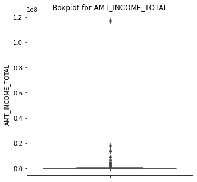

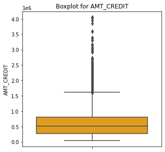

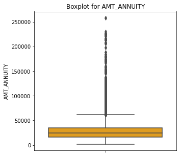

```python
ListofVar = ['AMT_INCOME_TOTAL','AMT_CREDIT','AMT_ANNUITY']
for var in ListofVar:
    boxp(CurrentAppl, var, 'orange')
```

- Box Plot for Amount Income has one data at extreme end which can be removed as it is effecting the data mean.
- Amount credit have outliers but data is continuous so better to keep these data as these can be a valid data.
- AMT_ANNUITY also have outliers but data is continuous so better to keep these data as these can be a valid data.

'AMT_ANNUITY' columns is having very few null values rows. Hence let's try to impute the missing values

Since this column is having an outlier which is very large it will be inappropriate to fill those missing values with mean, Hence Median comes to rescue for this and we will fill those missing banks with median value

```python
# Filling missing values with median

values=CurrentAppl['AMT_ANNUITY'].median()

CurrentAppl.loc[CurrentAppl['AMT_ANNUITY'].isnull(),'AMT_ANNUITY']=values
```

Days Birth, Days Employed, Days Registration and DAYS ID PUBLISH can not be in negative so converting them to the correct value.

```python
NegativecolumnList = ['DAYS_BIRTH','DAYS_EMPLOYED','DAYS_REGISTRATION','DAYS_ID_PUBLISH']
for var in NegativecolumnList:
    CurrentAppl[var] = CurrentAppl[var].abs()

CurrentAppl[['DAYS_BIRTH','DAYS_EMPLOYED','DAYS_REGISTRATION','DAYS_ID_PUBLISH']].head()
```

|  | DAYS_BIRTH | DAYS_EMPLOYED | DAYS_REGISTRATION | DAYS_ID_PUBLISH |
| --- | --- | --- | --- | --- |
| 0 | 9461 | 637 | 3648.0 | 2120 |
| 1 | 16765 | 1188 | 1186.0 | 291 |
| 2 | 19046 | 225 | 4260.0 | 2531 |
| 3 | 19005 | 3039 | 9833.0 | 2437 |
| 4 | 19932 | 3038 | 4311.0 | 3458 |

```python
#Converting Days BIrth to Age in Years and saving it new Column Age
CurrentAppl['Age'] = CurrentAppl.DAYS_BIRTH/365
CurrentAppl['Age'].head()
```

```
0    25.920548
1    45.931507
2    52.180822
3    52.068493
4    54.608219
Name: Age, dtype: float64
```

**Converting AMT_INCOME_TOTAL and AMT_CREDIT into catogories.**

#### Categorizing the data

**Derived Metrics**

```python
# Creating bins for AMT_INCOME_TOTAL

bins = [0,25000,50000,75000,100000,125000,150000,175000,200000,225000,250000,275000,300000,325000,350000,375000,400000,425000,450000,475000,500000,10000000000]
slot = ['0-25000', '25000-50000','50000-75000','75000,100000','100000-125000', '125000-150000', '150000-175000','175000-200000',
       '200000-225000','225000-250000','250000-275000','275000-300000','300000-325000','325000-350000','350000-375000',
       '375000-400000','400000-425000','425000-450000','450000-475000','475000-500000','500000 and above']

CurrentAppl['AMT_INCOME_RANGE']=pd.cut(CurrentAppl['AMT_INCOME_TOTAL'],bins,labels=slot)
```

```python
# Creating bins for Credit amount

bins = [0,150000,200000,250000,300000,350000,400000,450000,500000,550000,600000,650000,700000,750000,800000,850000,900000,1000000000]
slots = ['0-150000', '150000-200000','200000-250000', '250000-300000', '300000-350000', '350000-400000','400000-450000',
        '450000-500000','500000-550000','550000-600000','600000-650000','650000-700000','700000-750000','750000-800000',
        '800000-850000','850000-900000','900000 and above']

CurrentAppl['AMT_CREDIT_RANGE']=pd.cut(CurrentAppl['AMT_CREDIT'],bins=bins,labels=slots)
```

#### Finding any odd or wrongly structured value in data columns.

```python
VarColumns = ['TARGET', 'NAME_CONTRACT_TYPE', 'CODE_GENDER', 'FLAG_OWN_CAR', 'FLAG_OWN_REALTY', 'CNT_CHILDREN', 'NAME_INCOME_TYPE', 'NAME_EDUCATION_TYPE', 'NAME_FAMILY_STATUS', 'NAME_HOUSING_TYPE', 'ORGANIZATION_TYPE']
#Getting unique values
for x in VarColumns:
     a = CurrentAppl[str(x)].unique()
     print(x , 'has' , a)
```

```
TARGET has [1 0]
NAME_CONTRACT_TYPE has ['Cash loans' 'Revolving loans']
CODE_GENDER has ['M' 'F' 'XNA']
FLAG_OWN_CAR has ['N' 'Y']
FLAG_OWN_REALTY has ['Y' 'N']
CNT_CHILDREN has [ 0  1  2  3  4  7  5  6  8  9 11 12 10 19 14]
NAME_INCOME_TYPE has ['Working' 'State servant' 'Commercial associate' 'Pensioner' 'Unemployed'
 'Student' 'Businessman' 'Maternity leave']
NAME_EDUCATION_TYPE has ['Secondary / secondary special' 'Higher education' 'Incomplete higher'
 'Lower secondary' 'Academic degree']
NAME_FAMILY_STATUS has ['Single / not married' 'Married' 'Civil marriage' 'Widow' 'Separated'
 'Unknown']
NAME_HOUSING_TYPE has ['House / apartment' 'Rented apartment' 'With parents'
 'Municipal apartment' 'Office apartment' 'Co-op apartment']
ORGANIZATION_TYPE has ['Business Entity Type 3' 'School' 'Government' 'Religion' 'Other' 'XNA'
 'Electricity' 'Medicine' 'Business Entity Type 2' 'Self-employed'
 'Transport: type 2' 'Construction' 'Housing' 'Kindergarten'
 'Trade: type 7' 'Industry: type 11' 'Military' 'Services'
 'Security Ministries' 'Transport: type 4' 'Industry: type 1' 'Emergency'
 'Security' 'Trade: type 2' 'University' 'Transport: type 3' 'Police'
 'Business Entity Type 1' 'Postal' 'Industry: type 4' 'Agriculture'
 'Restaurant' 'Culture' 'Hotel' 'Industry: type 7' 'Trade: type 3'
 'Industry: type 3' 'Bank' 'Industry: type 9' 'Insurance' 'Trade: type 6'
 'Industry: type 2' 'Transport: type 1' 'Industry: type 12' 'Mobile'
 'Trade: type 1' 'Industry: type 5' 'Industry: type 10' 'Legal Services'
 'Advertising' 'Trade: type 5' 'Cleaning' 'Industry: type 13'
 'Trade: type 4' 'Telecom' 'Industry: type 8' 'Realtor' 'Industry: type 6']
```

There are some columns where the value is mentioned as 'XNA' which means 'Not Available'. So we have to find the number of rows and columns and implement suitable techniques on them to fill those missing values or to delete them.

```python
# let's find these categorical columns having these 'XNA' values

# For Gender column

CurrentAppl[CurrentAppl['CODE_GENDER']=='XNA'].shape
```

```
(4, 31)
```

```python
# For Organization column

CurrentAppl[CurrentAppl['ORGANIZATION_TYPE']=='XNA'].shape
```

```
(55374, 31)
```

So, there are 4 rows from Gender column and 55374 rows from Organization type column

```python
# Describing the Gender column to check the number of females and males

CurrentAppl['CODE_GENDER'].value_counts()
```

```
F      202448
M      105059
XNA         4
Name: CODE_GENDER, dtype: int64
```

```python
# Female are at majority and only 4 rows are having NA values, we can update those columns with Gender 'F' as there will be no impact on the dataset.
# Updating the column 'CODE_GENDER' with "F" for the dataset
CurrentAppl.loc[CurrentAppl['CODE_GENDER']=='XNA','CODE_GENDER']='F'
CurrentAppl['CODE_GENDER'].value_counts()
```

```
F    202452
M    105059
Name: CODE_GENDER, dtype: int64
```

```python
# Describing the organization type column

CurrentAppl['ORGANIZATION_TYPE'].describe()
```

```
count                     307511
unique                        58
top       Business Entity Type 3
freq                       67992
Name: ORGANIZATION_TYPE, dtype: object
```

- So, for column 'ORGANIZATION_TYPE', we have total count of 307511 rows of which 55374 rows are having 'XNA' values. Which means 18% of the column is having this values.
- if we drop the rows of total 55374, will not have any major impact on our dataset. But in this case study we are advised, not to go for droping. So will continue with the same.

```python
# Dividing the dataset into two dataset of  target=1(client with payment difficulties) and target=0(all other)

target0_df=CurrentAppl.loc[CurrentAppl["TARGET"]==0]
target1_df=CurrentAppl.loc[CurrentAppl["TARGET"]==1]
```

#### Calculating Imbalance percentage

```python
# Since the majority is target0 and minority is target1

ImbalancePr = round(len(target0_df)/len(target1_df),2)
print( 'The Imbalance ratio is', ImbalancePr)
```

```
The Imbalance ratio is 11.39
```

## Analysis on data with Target = 0 (No difficulties )

#### Univariate analysis for categorical Data

```python
def univar(df,col):
        # getting graph in decresing order of total number counts

    if len(df[col].unique()) > 6:
        fig, ax = plt.subplots()
        width = 5 #+ 4*len(temp.unique())
        fig.set_size_inches(15 , (width+len(df[col].unique())))
        plt.yticks(rotation=0, fontsize = 12)
        plt.xscale('log')
        plt.title(('Count for ' + col) )
        ax = sns.countplot(data = df, y= col, order=df[col].value_counts().index, orient='h')
        plt.show()
    else :
        fig, ax = plt.subplots()
        width = len(df[col].unique()) + 2 #+ 4*len(temp.unique())
        fig.set_size_inches(width , 8)
        plt.xticks(rotation=90,  fontsize = 12)
        plt.yscale('log')
        plt.title(('Count for ' + col) )
        ax = sns.countplot(data = df, x= col, order=df[col].value_counts().index, orient='v')
        plt.show()
```

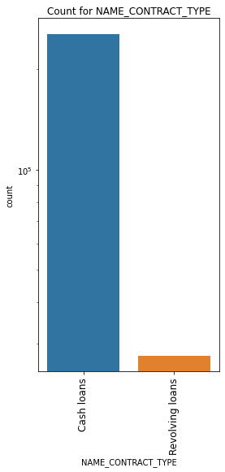

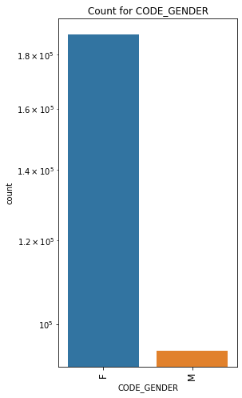

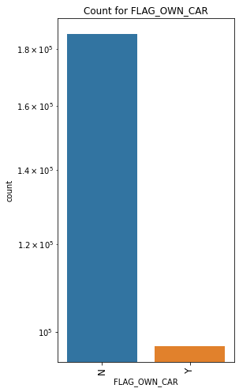

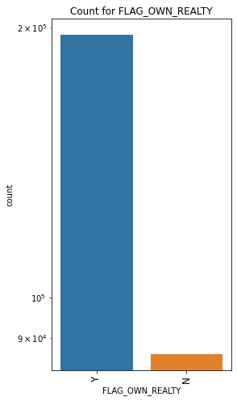

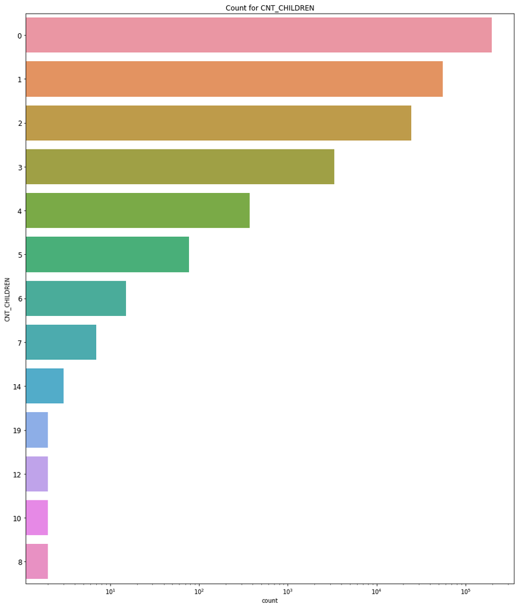

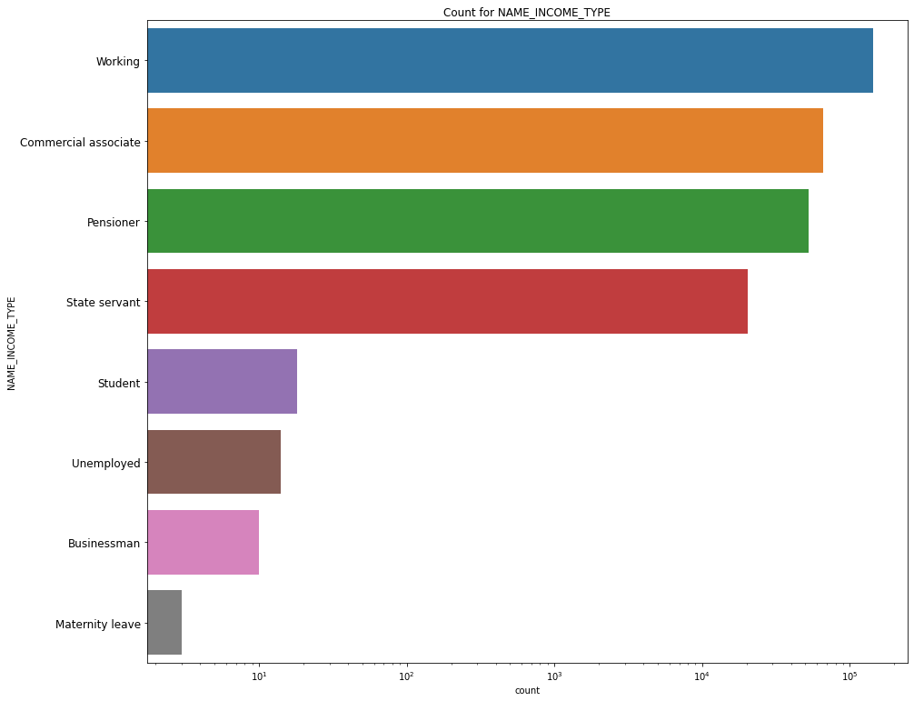

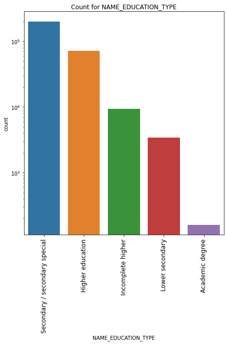

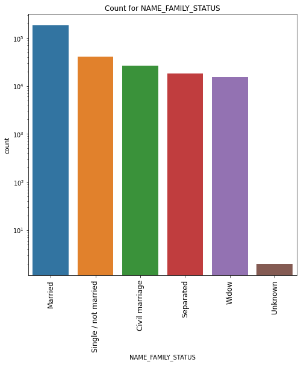

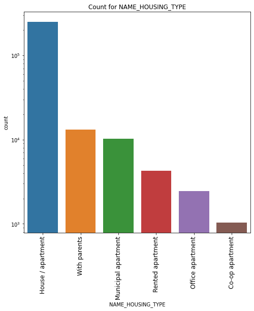

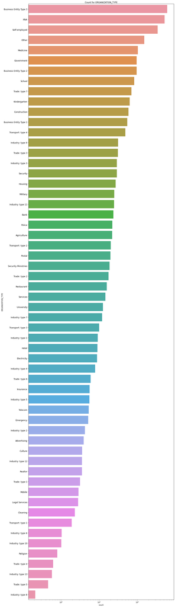

```python
# univariate plot
univarcat01 = ['NAME_CONTRACT_TYPE', 'CODE_GENDER', 'FLAG_OWN_CAR', 'FLAG_OWN_REALTY', 'CNT_CHILDREN', 'NAME_INCOME_TYPE', 'NAME_EDUCATION_TYPE', 'NAME_FAMILY_STATUS', 'NAME_HOUSING_TYPE', 'ORGANIZATION_TYPE']
for var in univarcat01:
    univar(target0_df,var)
```

**From the above plots we conclude**

```python
# Adding comments for graph
for var in univarcat01:
    univar0df = pd.DataFrame(target0_df[var].value_counts())
    univar0df.reset_index(inplace=True)
    df = univar0df.sort_values(by=var, ascending=False)
    print( var, '\n--------\nFor',var,', Clients with Target = 1 (Who had payment difficulties) maximum value is for ',df['index'][0])
    print( 'For',var,', Clients with Target = 1 (Who had payment difficulties) minimum value is for ',df['index'].iloc[-1],'\n--------\n')
```

```
NAME_CONTRACT_TYPE
--------
For NAME_CONTRACT_TYPE , Clients with Target = 1 (Who had payment difficulties) maximum value is for  Cash loans
For NAME_CONTRACT_TYPE , Clients with Target = 1 (Who had payment difficulties) minimum value is for  Revolving loans
--------

CODE_GENDER
--------
For CODE_GENDER , Clients with Target = 1 (Who had payment difficulties) maximum value is for  F
For CODE_GENDER , Clients with Target = 1 (Who had payment difficulties) minimum value is for  M
--------

FLAG_OWN_CAR
--------
For FLAG_OWN_CAR , Clients with Target = 1 (Who had payment difficulties) maximum value is for  N
For FLAG_OWN_CAR , Clients with Target = 1 (Who had payment difficulties) minimum value is for  Y
--------

FLAG_OWN_REALTY
--------
For FLAG_OWN_REALTY , Clients with Target = 1 (Who had payment difficulties) maximum value is for  Y
For FLAG_OWN_REALTY , Clients with Target = 1 (Who had payment difficulties) minimum value is for  N
--------

CNT_CHILDREN
--------
For CNT_CHILDREN , Clients with Target = 1 (Who had payment difficulties) maximum value is for  0
For CNT_CHILDREN , Clients with Target = 1 (Who had payment difficulties) minimum value is for  8
--------

NAME_INCOME_TYPE
--------
For NAME_INCOME_TYPE , Clients with Target = 1 (Who had payment difficulties) maximum value is for  Working
For NAME_INCOME_TYPE , Clients with Target = 1 (Who had payment difficulties) minimum value is for  Maternity leave
--------

NAME_EDUCATION_TYPE
--------
For NAME_EDUCATION_TYPE , Clients with Target = 1 (Who had payment difficulties) maximum value is for  Secondary / secondary special
For NAME_EDUCATION_TYPE , Clients with Target = 1 (Who had payment difficulties) minimum value is for  Academic degree
--------

NAME_FAMILY_STATUS
--------
For NAME_FAMILY_STATUS , Clients with Target = 1 (Who had payment difficulties) maximum value is for  Married
For NAME_FAMILY_STATUS , Clients with Target = 1 (Who had payment difficulties) minimum value is for  Unknown
--------

NAME_HOUSING_TYPE
--------
For NAME_HOUSING_TYPE , Clients with Target = 1 (Who had payment difficulties) maximum value is for  House / apartment
For NAME_HOUSING_TYPE , Clients with Target = 1 (Who had payment difficulties) minimum value is for  Co-op apartment
--------

ORGANIZATION_TYPE
--------
For ORGANIZATION_TYPE , Clients with Target = 1 (Who had payment difficulties) maximum value is for  Business Entity Type 3
For ORGANIZATION_TYPE , Clients with Target = 1 (Who had payment difficulties) minimum value is for  Industry: type 8
--------
```

#### Bivariate Analysis

Categorical **Bivariate Analysis** in logarithmic scale for target=0(client with no payment difficulties)

```python
# Count plotting in logarithmic scale

def biplot(df,col,title,hue =None):


    temp = pd.Series(data = hue)
    fig, ax = plt.subplots()
    width = len(df[col].unique()) + 7 + 4*len(temp.unique())
    fig.set_size_inches(width , 8)
    plt.xticks(rotation=45)
    plt.yscale('log')
    plt.title(title)
    # getting graph in decresing order of total number counts
    ax = sns.countplot(data = df, x= col, order=df[col].value_counts().index, hue = hue,palette='magma')

    plt.show()
```

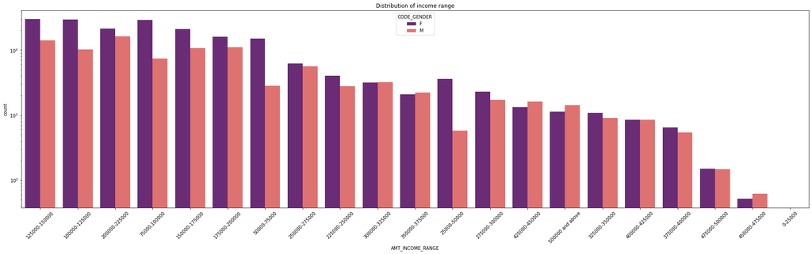

```python
# PLotting for income range
biplot(target0_df,col='AMT_INCOME_RANGE',title='Distribution of income range',hue='CODE_GENDER')
```

From the above graph we can conslude.

- Female counts are higher than male.
- Income range from 100000 to 150000 is having more number of counts.
- This graph shows that females are more than male in having credits for above mentioned range.
- Very less count for income range 400000 and 500000.

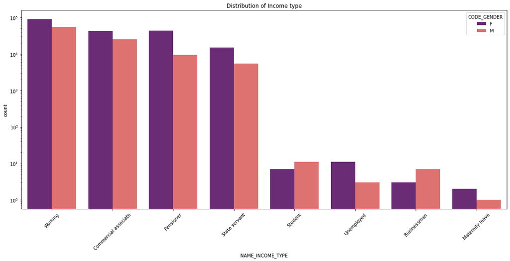

```python
# Plotting for Income type

biplot(target0_df,col='NAME_INCOME_TYPE',title='Distribution of Income type',hue='CODE_GENDER')
```

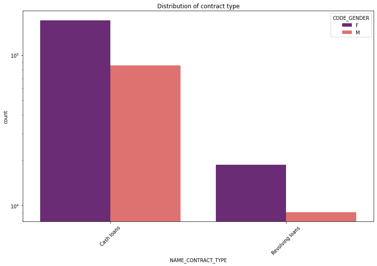

```python
# Plotting for Contract type

biplot(target0_df,col='NAME_CONTRACT_TYPE',title='Distribution of contract type',hue='CODE_GENDER')
```

Points we can concluded from the above graph.

- Contract type ‘cash loans’ is having higher number of credits than ‘Revolving loans’ contract type.
- Here also Females more in count in both the Contract types.

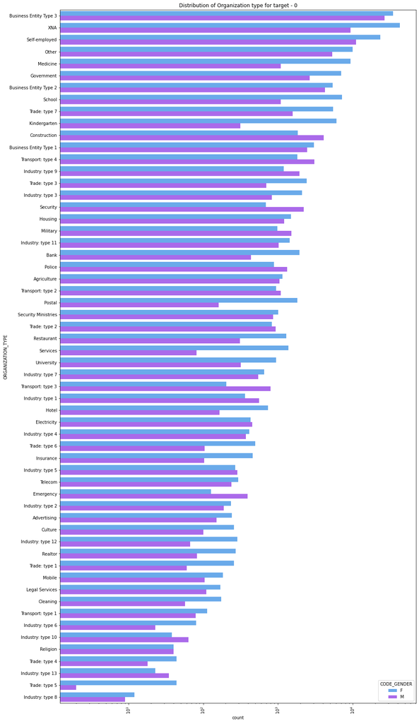

```python
# Plotting for Organization type in logarithmic scale

plt.figure(figsize=(15,30))
plt.title("Distribution of Organization type for target - 0")
plt.xticks(rotation=90)
plt.xscale('log')
sns.countplot(data=target0_df,y='ORGANIZATION_TYPE',order=target0_df['ORGANIZATION_TYPE'].value_counts().index,palette='cool',hue='CODE_GENDER')
plt.show()
```

Points to be concluded from the above graph.

- A huge group also belong to the data having blank values for ORGANIZATION TYPE. If we drop that *(Not dropped here as per suggestion given in problem statement - II of Task)* we have higher number of Clients which have applied for credits are from most of the organization type ‘Business entity Type 3’ , ‘Self employed’, ‘Other’ , ‘Medicine’ and ‘Government’.
- Less clients are from Industry type 8,type 6, type 10, religion and trade type 5, type 4.

## Analysis on data with Target = 1 (Payment difficulties )

#### Univariate analysis for categorical Data

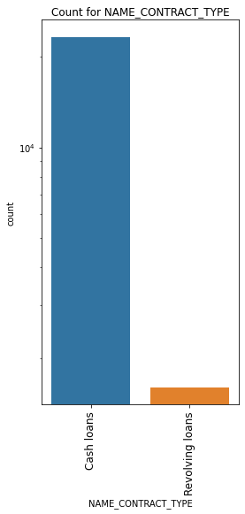

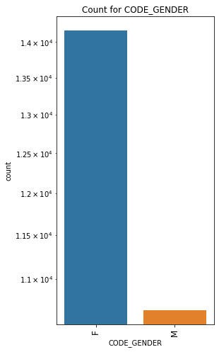

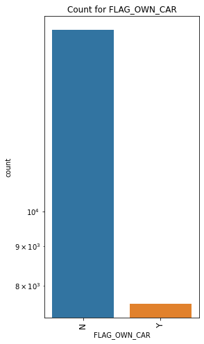

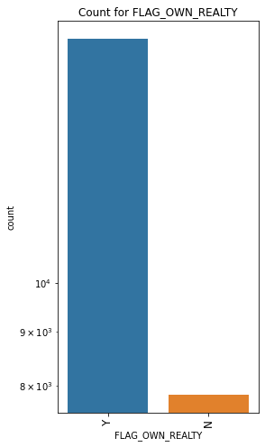

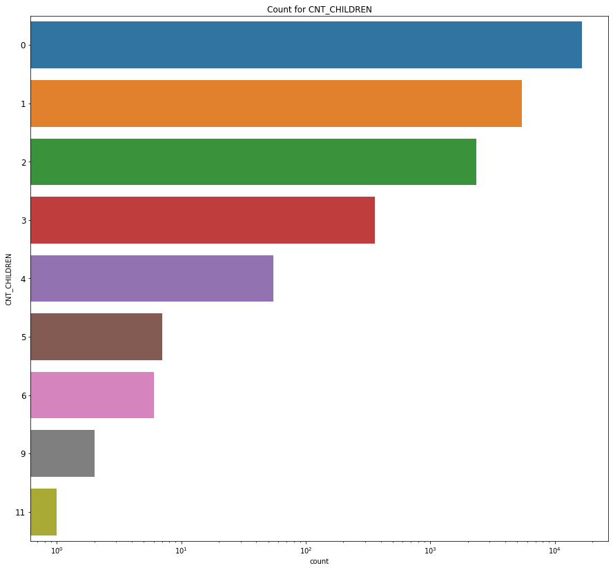

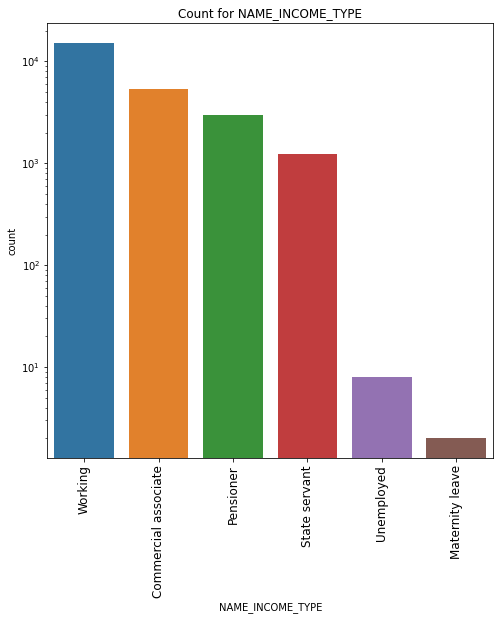

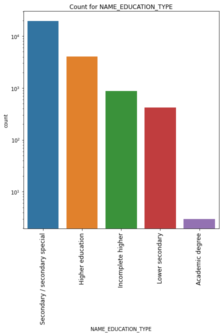

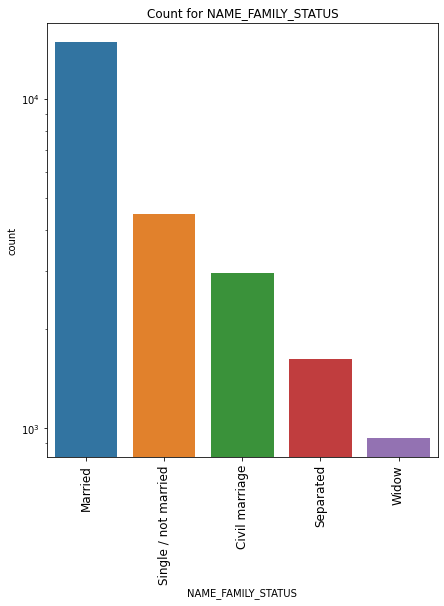

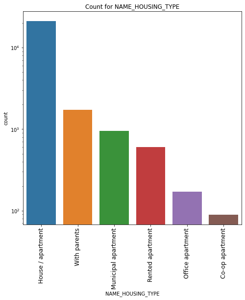

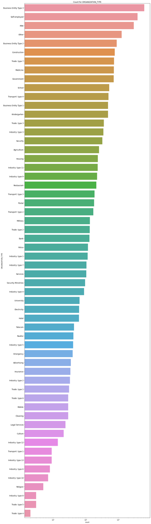

```python
univarcat1l = ['NAME_CONTRACT_TYPE', 'CODE_GENDER', 'FLAG_OWN_CAR', 'FLAG_OWN_REALTY', 'CNT_CHILDREN', 'NAME_INCOME_TYPE', 'NAME_EDUCATION_TYPE', 'NAME_FAMILY_STATUS', 'NAME_HOUSING_TYPE', 'ORGANIZATION_TYPE']
for var in univarcat1l:
    univar(target1_df,var)
```

#### From above plots , we conclude the following

```python
# Adding comments for graph
for var in univarcat1l:
    univar1df = pd.DataFrame(target1_df[var].value_counts())
    univar1df.reset_index(inplace=True)
    maxdf = univar1df.sort_values(by=var, ascending=False)
    print( var, '\n--------\nFor',var,', Clients with Target = 1 (Who had payment difficulties) maximum value is for ',maxdf['index'][0])
    print( 'For',var,', Clients with Target = 1 (Who had payment difficulties) minimum value is for ',maxdf['index'].iloc[-1],'\n--------\n')
```

```
NAME_CONTRACT_TYPE
--------
For NAME_CONTRACT_TYPE , Clients with Target = 1 (Who had payment difficulties) maximum value is for  Cash loans
For NAME_CONTRACT_TYPE , Clients with Target = 1 (Who had payment difficulties) minimum value is for  Revolving loans
--------

CODE_GENDER
--------
For CODE_GENDER , Clients with Target = 1 (Who had payment difficulties) maximum value is for  F
For CODE_GENDER , Clients with Target = 1 (Who had payment difficulties) minimum value is for  M
--------

FLAG_OWN_CAR
--------
For FLAG_OWN_CAR , Clients with Target = 1 (Who had payment difficulties) maximum value is for  N
For FLAG_OWN_CAR , Clients with Target = 1 (Who had payment difficulties) minimum value is for  Y
--------

FLAG_OWN_REALTY
--------
For FLAG_OWN_REALTY , Clients with Target = 1 (Who had payment difficulties) maximum value is for  Y
For FLAG_OWN_REALTY , Clients with Target = 1 (Who had payment difficulties) minimum value is for  N
--------

CNT_CHILDREN
--------
For CNT_CHILDREN , Clients with Target = 1 (Who had payment difficulties) maximum value is for  0
For CNT_CHILDREN , Clients with Target = 1 (Who had payment difficulties) minimum value is for  11
--------

NAME_INCOME_TYPE
--------
For NAME_INCOME_TYPE , Clients with Target = 1 (Who had payment difficulties) maximum value is for  Working
For NAME_INCOME_TYPE , Clients with Target = 1 (Who had payment difficulties) minimum value is for  Maternity leave
--------

NAME_EDUCATION_TYPE
--------
For NAME_EDUCATION_TYPE , Clients with Target = 1 (Who had payment difficulties) maximum value is for  Secondary / secondary special
For NAME_EDUCATION_TYPE , Clients with Target = 1 (Who had payment difficulties) minimum value is for  Academic degree
--------

NAME_FAMILY_STATUS
--------
For NAME_FAMILY_STATUS , Clients with Target = 1 (Who had payment difficulties) maximum value is for  Married
For NAME_FAMILY_STATUS , Clients with Target = 1 (Who had payment difficulties) minimum value is for  Widow
--------

NAME_HOUSING_TYPE
--------
For NAME_HOUSING_TYPE , Clients with Target = 1 (Who had payment difficulties) maximum value is for  House / apartment
For NAME_HOUSING_TYPE , Clients with Target = 1 (Who had payment difficulties) minimum value is for  Co-op apartment
--------

ORGANIZATION_TYPE
--------
For ORGANIZATION_TYPE , Clients with Target = 1 (Who had payment difficulties) maximum value is for  Business Entity Type 3
For ORGANIZATION_TYPE , Clients with Target = 1 (Who had payment difficulties) minimum value is for  Trade: type 4
--------
```

#### Categoroical Bivariate Analysis in logarithmic scale for target=1(client with payment difficulties)

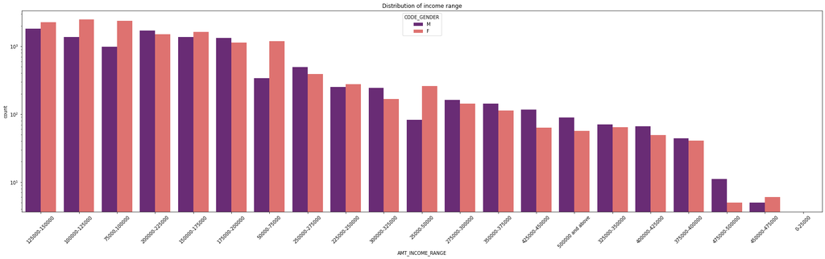

```python
# PLotting for income range

biplot(target1_df,col='AMT_INCOME_RANGE',title='Distribution of income range',hue='CODE_GENDER')
```

Points to be concluded from the above graph.

- Female counts are higher than Male.
- Income range from 100000 to 200000 is having more number of applications.

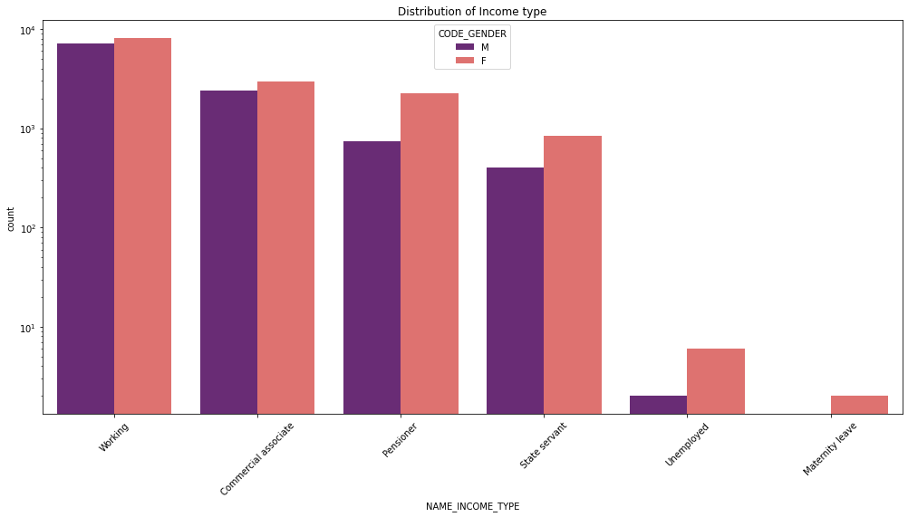

```python
# Plotting for Income type

biplot(target1_df,col='NAME_INCOME_TYPE',title='Distribution of Income type',hue='CODE_GENDER')
```

Points to conclude from the above graph.

1. For income type ‘working’, ’commercial associate’, 'Pensioner' and ‘State Servant’ the number of credits are higher than others.
2. Females and Males are having almost same number for working and commercial associate income type.
3. Less number are found for income type ‘Maternity leave’.

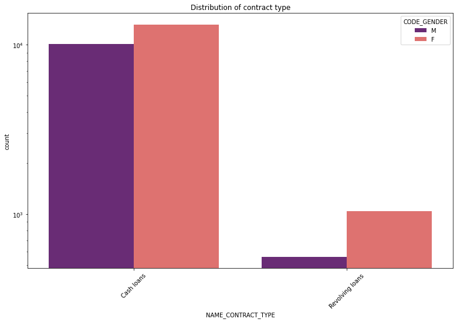

```python
# Plotting for Contract type

biplot(target1_df,col='NAME_CONTRACT_TYPE',title='Distribution of contract type',hue='CODE_GENDER')
```

Conclusion from the above graph.

1. For contract type ‘cash loans’ is having higher number of credits than ‘Revolving loans’ contract type.
2. Females are more in count.
3. For type 1 : there is very high Female counts for Revolving loans.

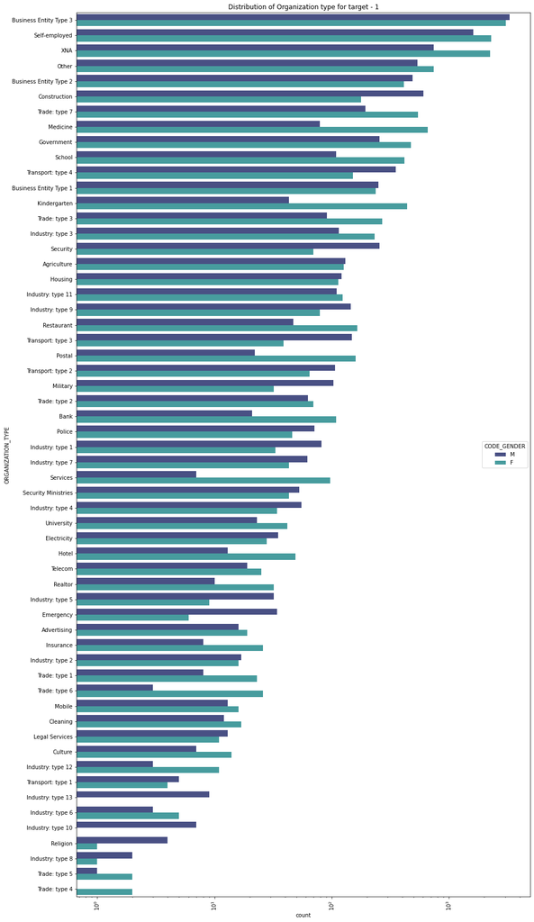

```python
# Plotting for Organization type

plt.figure(figsize=(15,30))
plt.title("Distribution of Organization type for target - 1")
plt.xticks(rotation=90)
plt.xscale('log')
sns.countplot(data=target1_df,y='ORGANIZATION_TYPE',order=target1_df['ORGANIZATION_TYPE'].value_counts().index,palette='mako',hue='CODE_GENDER')
plt.show()
```

Points to be concluded from the above graph.

1. Clients which have applied for credits are from most of the organization type ‘Business entity Type 3’ , ‘Self employed’ , ‘Other’ , ‘Medicine’ and ‘Government’.
2. Less clients are from Industry type 8,type 6, type 10, religion and trade type 5, type 4.
3. It is almost Same as target 0 in distribution of organization type.

#### Correlation

```python
# Now, plotting the above correlation with heat map as it is the best choice to visulaize

# figure size

def targets_corr(data,title):
    plt.figure(figsize=(15, 10))

# heatmap with a color map of choice

    sns.heatmap(data, cmap="RdYlGn",annot=True, annot_kws={"size":12})

    plt.title(title)
    plt.yticks(rotation=0, fontsize=15)
    plt.xticks(fontsize=15)

    plt.show()
```

```python
# Finding some correlation for numerical columns for both target 0 and 1

target0_corr=target0_df.iloc[0:,2:]
target1_corr=target1_df.iloc[0:,2:]

target0=target0_corr.corr(method='spearman')
target1=target1_corr.corr(method='spearman')
total0and1 = CurrentAppl.corr(method='spearman')
```

```python
total0and1 = round(total0and1,2)
total0and1.drop(labels='SK_ID_CURR', axis=1, inplace=True )
total0and1.drop(labels='SK_ID_CURR', axis=0, inplace=True )
total0and1
```

|  | TARGET | CNT_CHILDREN | AMT_INCOME_TOTAL | AMT_CREDIT | AMT_ANNUITY | REGION_POPULATION_RELATIVE | DAYS_BIRTH | DAYS_EMPLOYED | DAYS_REGISTRATION | DAYS_ID_PUBLISH | HOUR_APPR_PROCESS_START | REG_REGION_NOT_LIVE_REGION | REG_REGION_NOT_WORK_REGION | LIVE_REGION_NOT_WORK_REGION | REG_CITY_NOT_LIVE_CITY | REG_CITY_NOT_WORK_CITY | LIVE_CITY_NOT_WORK_CITY | Age |
| --- | --- | --- | --- | --- | --- | --- | --- | --- | --- | --- | --- | --- | --- | --- | --- | --- | --- | --- |
| TARGET | 1.00 | 0.02 | -0.02 | -0.02 | -0.00 | -0.03 | -0.08 | -0.09 | -0.04 | -0.05 | -0.02 | 0.01 | 0.01 | 0.00 | 0.04 | 0.05 | 0.03 | -0.08 |
| CNT_CHILDREN | 0.02 | 1.00 | 0.03 | 0.00 | 0.03 | -0.03 | -0.37 | -0.20 | -0.18 | 0.02 | -0.00 | -0.01 | 0.01 | 0.02 | 0.03 | 0.07 | 0.07 | -0.37 |
| AMT_INCOME_TOTAL | -0.02 | 0.03 | 1.00 | 0.41 | 0.48 | 0.09 | -0.08 | -0.09 | -0.07 | -0.03 | 0.10 | 0.08 | 0.16 | 0.15 | 0.02 | 0.04 | 0.04 | -0.08 |
| AMT_CREDIT | -0.02 | 0.00 | 0.41 | 1.00 | 0.83 | 0.05 | 0.07 | 0.02 | -0.01 | 0.01 | 0.05 | 0.02 | 0.04 | 0.05 | -0.03 | -0.01 | 0.00 | 0.07 |
| AMT_ANNUITY | -0.00 | 0.03 | 0.48 | 0.83 | 1.00 | 0.06 | -0.01 | -0.03 | -0.04 | -0.01 | 0.05 | 0.04 | 0.07 | 0.07 | -0.00 | 0.01 | 0.02 | -0.01 |
| REGION_POPULATION_RELATIVE | -0.03 | -0.03 | 0.09 | 0.05 | 0.06 | 1.00 | 0.03 | 0.00 | 0.04 | 0.01 | 0.13 | -0.02 | 0.03 | 0.05 | -0.05 | -0.03 | -0.01 | 0.03 |
| DAYS_BIRTH | -0.08 | -0.37 | -0.08 | 0.07 | -0.01 | 0.03 | 1.00 | 0.58 | 0.30 | 0.26 | -0.09 | -0.07 | -0.09 | -0.07 | -0.18 | -0.24 | -0.15 | 1.00 |
| DAYS_EMPLOYED | -0.09 | -0.20 | -0.09 | 0.02 | -0.03 | 0.00 | 0.58 | 1.00 | 0.20 | 0.26 | -0.08 | -0.07 | -0.14 | -0.11 | -0.15 | -0.26 | -0.20 | 0.58 |
| DAYS_REGISTRATION | -0.04 | -0.18 | -0.07 | -0.01 | -0.04 | 0.04 | 0.30 | 0.20 | 1.00 | 0.10 | 0.01 | -0.03 | -0.03 | -0.02 | -0.05 | -0.09 | -0.06 | 0.30 |
| DAYS_ID_PUBLISH | -0.05 | 0.02 | -0.03 | 0.01 | -0.01 | 0.01 | 0.26 | 0.26 | 0.10 | 1.00 | -0.04 | -0.04 | -0.05 | -0.03 | -0.08 | -0.10 | -0.06 | 0.26 |
| HOUR_APPR_PROCESS_START | -0.02 | -0.00 | 0.10 | 0.05 | 0.05 | 0.13 | -0.09 | -0.08 | 0.01 | -0.04 | 1.00 | 0.05 | 0.07 | 0.06 | 0.02 | 0.02 | 0.01 | -0.09 |
| REG_REGION_NOT_LIVE_REGION | 0.01 | -0.01 | 0.08 | 0.02 | 0.04 | -0.02 | -0.07 | -0.07 | -0.03 | -0.04 | 0.05 | 1.00 | 0.45 | 0.09 | 0.34 | 0.14 | 0.01 | -0.07 |
| REG_REGION_NOT_WORK_REGION | 0.01 | 0.01 | 0.16 | 0.04 | 0.07 | 0.03 | -0.09 | -0.14 | -0.03 | -0.05 | 0.07 | 0.45 | 1.00 | 0.86 | 0.15 | 0.24 | 0.20 | -0.09 |
| LIVE_REGION_NOT_WORK_REGION | 0.00 | 0.02 | 0.15 | 0.05 | 0.07 | 0.05 | -0.07 | -0.11 | -0.02 | -0.03 | 0.06 | 0.09 | 0.86 | 1.00 | 0.02 | 0.19 | 0.24 | -0.07 |
| REG_CITY_NOT_LIVE_CITY | 0.04 | 0.03 | 0.02 | -0.03 | -0.00 | -0.05 | -0.18 | -0.15 | -0.05 | -0.08 | 0.02 | 0.34 | 0.15 | 0.02 | 1.00 | 0.44 | 0.03 | -0.18 |
| REG_CITY_NOT_WORK_CITY | 0.05 | 0.07 | 0.04 | -0.01 | 0.01 | -0.03 | -0.24 | -0.26 | -0.09 | -0.10 | 0.02 | 0.14 | 0.24 | 0.19 | 0.44 | 1.00 | 0.83 | -0.24 |
| LIVE_CITY_NOT_WORK_CITY | 0.03 | 0.07 | 0.04 | 0.00 | 0.02 | -0.01 | -0.15 | -0.20 | -0.06 | -0.06 | 0.01 | 0.01 | 0.20 | 0.24 | 0.03 | 0.83 | 1.00 | -0.15 |
| Age | -0.08 | -0.37 | -0.08 | 0.07 | -0.01 | 0.03 | 1.00 | 0.58 | 0.30 | 0.26 | -0.09 | -0.07 | -0.09 | -0.07 | -0.18 | -0.24 | -0.15 | 1.00 |

```python
# Correlation for target 0

target0 = round(target0,2)
target0
```

|  | CNT_CHILDREN | AMT_INCOME_TOTAL | AMT_CREDIT | AMT_ANNUITY | REGION_POPULATION_RELATIVE | DAYS_BIRTH | DAYS_EMPLOYED | DAYS_REGISTRATION | DAYS_ID_PUBLISH | HOUR_APPR_PROCESS_START | REG_REGION_NOT_LIVE_REGION | REG_REGION_NOT_WORK_REGION | LIVE_REGION_NOT_WORK_REGION | REG_CITY_NOT_LIVE_CITY | REG_CITY_NOT_WORK_CITY | LIVE_CITY_NOT_WORK_CITY | Age |
| --- | --- | --- | --- | --- | --- | --- | --- | --- | --- | --- | --- | --- | --- | --- | --- | --- | --- |
| CNT_CHILDREN | 1.00 | 0.04 | 0.00 | 0.02 | -0.03 | -0.38 | -0.21 | -0.18 | 0.02 | 0.00 | -0.01 | 0.02 | 0.02 | 0.03 | 0.08 | 0.07 | -0.38 |
| AMT_INCOME_TOTAL | 0.04 | 1.00 | 0.42 | 0.49 | 0.10 | -0.09 | -0.10 | -0.08 | -0.04 | 0.10 | 0.08 | 0.16 | 0.15 | 0.02 | 0.04 | 0.04 | -0.09 |
| AMT_CREDIT | 0.00 | 0.42 | 1.00 | 0.83 | 0.05 | 0.06 | 0.02 | -0.01 | 0.00 | 0.05 | 0.02 | 0.05 | 0.05 | -0.03 | -0.01 | 0.01 | 0.06 |
| AMT_ANNUITY | 0.02 | 0.49 | 0.83 | 1.00 | 0.06 | -0.01 | -0.03 | -0.04 | -0.02 | 0.05 | 0.04 | 0.08 | 0.07 | -0.00 | 0.01 | 0.02 | -0.01 |
| REGION_POPULATION_RELATIVE | -0.03 | 0.10 | 0.05 | 0.06 | 1.00 | 0.03 | -0.00 | 0.04 | 0.01 | 0.13 | -0.02 | 0.03 | 0.05 | -0.05 | -0.03 | -0.01 | 0.03 |
| DAYS_BIRTH | -0.38 | -0.09 | 0.06 | -0.01 | 0.03 | 1.00 | 0.58 | 0.30 | 0.26 | -0.10 | -0.07 | -0.10 | -0.07 | -0.18 | -0.24 | -0.16 | 1.00 |
| DAYS_EMPLOYED | -0.21 | -0.10 | 0.02 | -0.03 | -0.00 | 0.58 | 1.00 | 0.20 | 0.26 | -0.08 | -0.07 | -0.14 | -0.11 | -0.15 | -0.26 | -0.20 | 0.58 |
| DAYS_REGISTRATION | -0.18 | -0.08 | -0.01 | -0.04 | 0.04 | 0.30 | 0.20 | 1.00 | 0.09 | 0.01 | -0.03 | -0.03 | -0.02 | -0.06 | -0.09 | -0.06 | 0.30 |
| DAYS_ID_PUBLISH | 0.02 | -0.04 | 0.00 | -0.02 | 0.01 | 0.26 | 0.26 | 0.09 | 1.00 | -0.04 | -0.04 | -0.05 | -0.03 | -0.08 | -0.10 | -0.06 | 0.26 |
| HOUR_APPR_PROCESS_START | 0.00 | 0.10 | 0.05 | 0.05 | 0.13 | -0.10 | -0.08 | 0.01 | -0.04 | 1.00 | 0.05 | 0.07 | 0.06 | 0.02 | 0.02 | 0.01 | -0.10 |
| REG_REGION_NOT_LIVE_REGION | -0.01 | 0.08 | 0.02 | 0.04 | -0.02 | -0.07 | -0.07 | -0.03 | -0.04 | 0.05 | 1.00 | 0.45 | 0.09 | 0.34 | 0.14 | 0.01 | -0.07 |
| REG_REGION_NOT_WORK_REGION | 0.02 | 0.16 | 0.05 | 0.08 | 0.03 | -0.10 | -0.14 | -0.03 | -0.05 | 0.07 | 0.45 | 1.00 | 0.86 | 0.15 | 0.24 | 0.20 | -0.10 |
| LIVE_REGION_NOT_WORK_REGION | 0.02 | 0.15 | 0.05 | 0.07 | 0.05 | -0.07 | -0.11 | -0.02 | -0.03 | 0.06 | 0.09 | 0.86 | 1.00 | 0.02 | 0.19 | 0.24 | -0.07 |
| REG_CITY_NOT_LIVE_CITY | 0.03 | 0.02 | -0.03 | -0.00 | -0.05 | -0.18 | -0.15 | -0.06 | -0.08 | 0.02 | 0.34 | 0.15 | 0.02 | 1.00 | 0.44 | 0.03 | -0.18 |
| REG_CITY_NOT_WORK_CITY | 0.08 | 0.04 | -0.01 | 0.01 | -0.03 | -0.24 | -0.26 | -0.09 | -0.10 | 0.02 | 0.14 | 0.24 | 0.19 | 0.44 | 1.00 | 0.83 | -0.24 |
| LIVE_CITY_NOT_WORK_CITY | 0.07 | 0.04 | 0.01 | 0.02 | -0.01 | -0.16 | -0.20 | -0.06 | -0.06 | 0.01 | 0.01 | 0.20 | 0.24 | 0.03 | 0.83 | 1.00 | -0.16 |
| Age | -0.38 | -0.09 | 0.06 | -0.01 | 0.03 | 1.00 | 0.58 | 0.30 | 0.26 | -0.10 | -0.07 | -0.10 | -0.07 | -0.18 | -0.24 | -0.16 | 1.00 |

```python
# Correlation for target 1

target1 = round(target1,2)
target1
```

|  | CNT_CHILDREN | AMT_INCOME_TOTAL | AMT_CREDIT | AMT_ANNUITY | REGION_POPULATION_RELATIVE | DAYS_BIRTH | DAYS_EMPLOYED | DAYS_REGISTRATION | DAYS_ID_PUBLISH | HOUR_APPR_PROCESS_START | REG_REGION_NOT_LIVE_REGION | REG_REGION_NOT_WORK_REGION | LIVE_REGION_NOT_WORK_REGION | REG_CITY_NOT_LIVE_CITY | REG_CITY_NOT_WORK_CITY | LIVE_CITY_NOT_WORK_CITY | Age |
| --- | --- | --- | --- | --- | --- | --- | --- | --- | --- | --- | --- | --- | --- | --- | --- | --- | --- |
| CNT_CHILDREN | 1.00 | -0.00 | 0.00 | 0.03 | -0.03 | -0.27 | -0.13 | -0.13 | 0.03 | -0.02 | -0.03 | -0.02 | -0.01 | 0.00 | 0.05 | 0.05 | -0.27 |
| AMT_INCOME_TOTAL | -0.00 | 1.00 | 0.36 | 0.43 | 0.05 | 0.01 | -0.04 | -0.04 | 0.01 | 0.09 | 0.08 | 0.16 | 0.14 | 0.01 | 0.03 | 0.03 | 0.01 |
| AMT_CREDIT | 0.00 | 0.36 | 1.00 | 0.81 | 0.04 | 0.16 | 0.08 | 0.02 | 0.05 | 0.03 | 0.01 | 0.03 | 0.03 | -0.03 | -0.03 | -0.01 | 0.16 |
| AMT_ANNUITY | 0.03 | 0.43 | 0.81 | 1.00 | 0.02 | 0.03 | -0.00 | -0.04 | 0.01 | 0.03 | 0.03 | 0.06 | 0.06 | -0.00 | 0.01 | 0.01 | 0.03 |
| REGION_POPULATION_RELATIVE | -0.03 | 0.05 | 0.04 | 0.02 | 1.00 | 0.05 | 0.02 | 0.03 | 0.02 | 0.11 | -0.03 | -0.01 | 0.01 | -0.06 | -0.04 | -0.02 | 0.05 |
| DAYS_BIRTH | -0.27 | 0.01 | 0.16 | 0.03 | 0.05 | 1.00 | 0.47 | 0.23 | 0.25 | -0.07 | -0.06 | -0.06 | -0.04 | -0.17 | -0.20 | -0.11 | 1.00 |
| DAYS_EMPLOYED | -0.13 | -0.04 | 0.08 | -0.00 | 0.02 | 0.47 | 1.00 | 0.15 | 0.21 | -0.04 | -0.08 | -0.12 | -0.09 | -0.14 | -0.25 | -0.17 | 0.47 |
| DAYS_REGISTRATION | -0.13 | -0.04 | 0.02 | -0.04 | 0.03 | 0.23 | 0.15 | 1.00 | 0.10 | 0.03 | -0.02 | -0.01 | -0.01 | -0.03 | -0.07 | -0.05 | 0.23 |
| DAYS_ID_PUBLISH | 0.03 | 0.01 | 0.05 | 0.01 | 0.02 | 0.25 | 0.21 | 0.10 | 1.00 | -0.03 | -0.03 | -0.03 | -0.02 | -0.07 | -0.07 | -0.03 | 0.25 |
| HOUR_APPR_PROCESS_START | -0.02 | 0.09 | 0.03 | 0.03 | 0.11 | -0.07 | -0.04 | 0.03 | -0.03 | 1.00 | 0.05 | 0.07 | 0.05 | 0.01 | 0.02 | 0.01 | -0.07 |
| REG_REGION_NOT_LIVE_REGION | -0.03 | 0.08 | 0.01 | 0.03 | -0.03 | -0.06 | -0.08 | -0.02 | -0.03 | 0.05 | 1.00 | 0.50 | 0.07 | 0.32 | 0.15 | -0.01 | -0.06 |
| REG_REGION_NOT_WORK_REGION | -0.02 | 0.16 | 0.03 | 0.06 | -0.01 | -0.06 | -0.12 | -0.01 | -0.03 | 0.07 | 0.50 | 1.00 | 0.85 | 0.14 | 0.24 | 0.19 | -0.06 |
| LIVE_REGION_NOT_WORK_REGION | -0.01 | 0.14 | 0.03 | 0.06 | 0.01 | -0.04 | -0.09 | -0.01 | -0.02 | 0.05 | 0.07 | 0.85 | 1.00 | -0.00 | 0.18 | 0.24 | -0.04 |
| REG_CITY_NOT_LIVE_CITY | 0.00 | 0.01 | -0.03 | -0.00 | -0.06 | -0.17 | -0.14 | -0.03 | -0.07 | 0.01 | 0.32 | 0.14 | -0.00 | 1.00 | 0.47 | -0.01 | -0.17 |
| REG_CITY_NOT_WORK_CITY | 0.05 | 0.03 | -0.03 | 0.01 | -0.04 | -0.20 | -0.25 | -0.07 | -0.07 | 0.02 | 0.15 | 0.24 | 0.18 | 0.47 | 1.00 | 0.78 | -0.20 |
| LIVE_CITY_NOT_WORK_CITY | 0.05 | 0.03 | -0.01 | 0.01 | -0.02 | -0.11 | -0.17 | -0.05 | -0.03 | 0.01 | -0.01 | 0.19 | 0.24 | -0.01 | 0.78 | 1.00 | -0.11 |
| Age | -0.27 | 0.01 | 0.16 | 0.03 | 0.05 | 1.00 | 0.47 | 0.23 | 0.25 | -0.07 | -0.06 | -0.06 | -0.04 | -0.17 | -0.20 | -0.11 | 1.00 |